# Final Project: Data Analysis

Mandy Klehr – I worked with Matt, Bonnie, and John

12/16/2021

# Data Exploration

## Numerical Exploration

```r
require(here)
delomys = read.csv(here("data", "delomys.csv"))

summary(delomys$body_mass)
```

```
##    Min. 1st Qu.  Median    Mean 3rd Qu.    Max.
##    5.00   35.00   43.00   44.06   54.00  105.00
```

```r
summary(delomys$body_length)
```

```
##    Min. 1st Qu.  Median    Mean 3rd Qu.    Max.
##    49.0   106.0   116.0   114.7   124.0   265.0
```

```r
shapiro.test(delomys$body_mass)
```

```
##
##  Shapiro-Wilk normality test
##
## data:  delomys$body_mass
## W = 0.99506, p-value = 4.33e-05
```

```r
shapiro.test(delomys$body_length)
```

```
##
##  Shapiro-Wilk normality test
##
## data:  delomys$body_length
## W = 0.87609, p-value < 2.2e-16
```

## Graphical Exploration

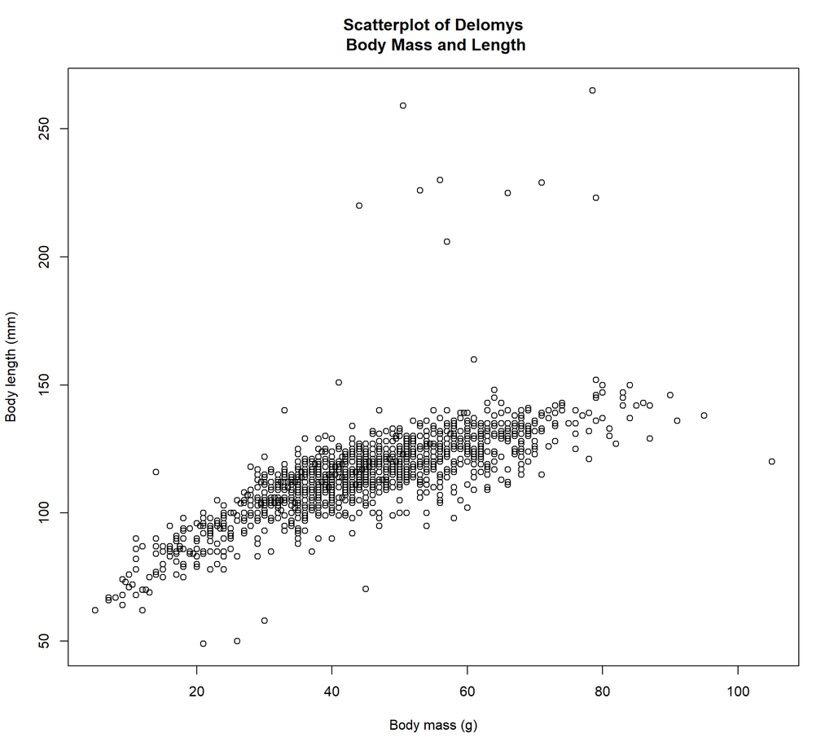

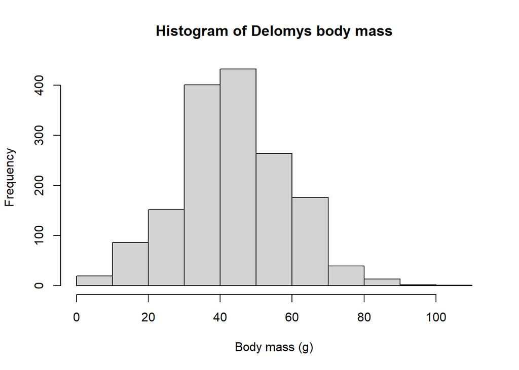

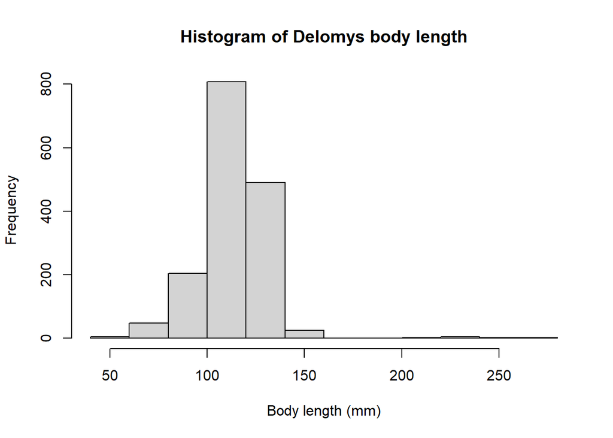

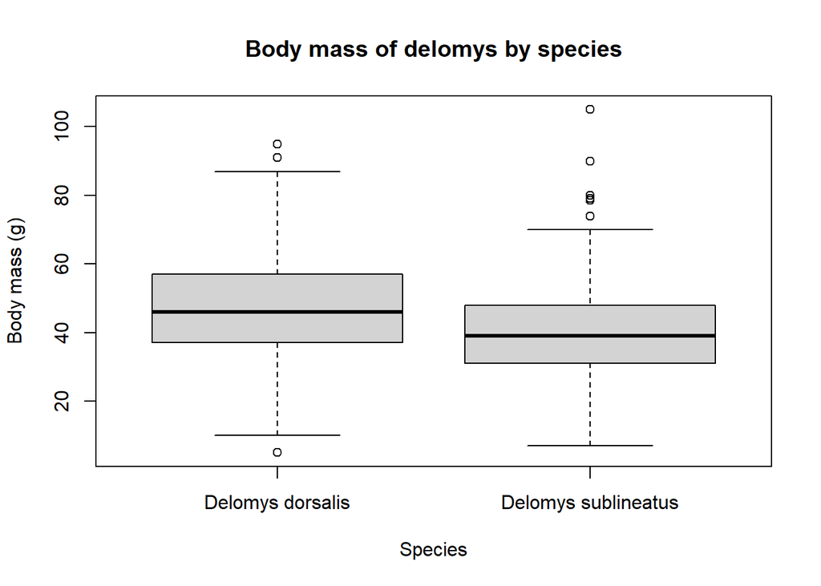

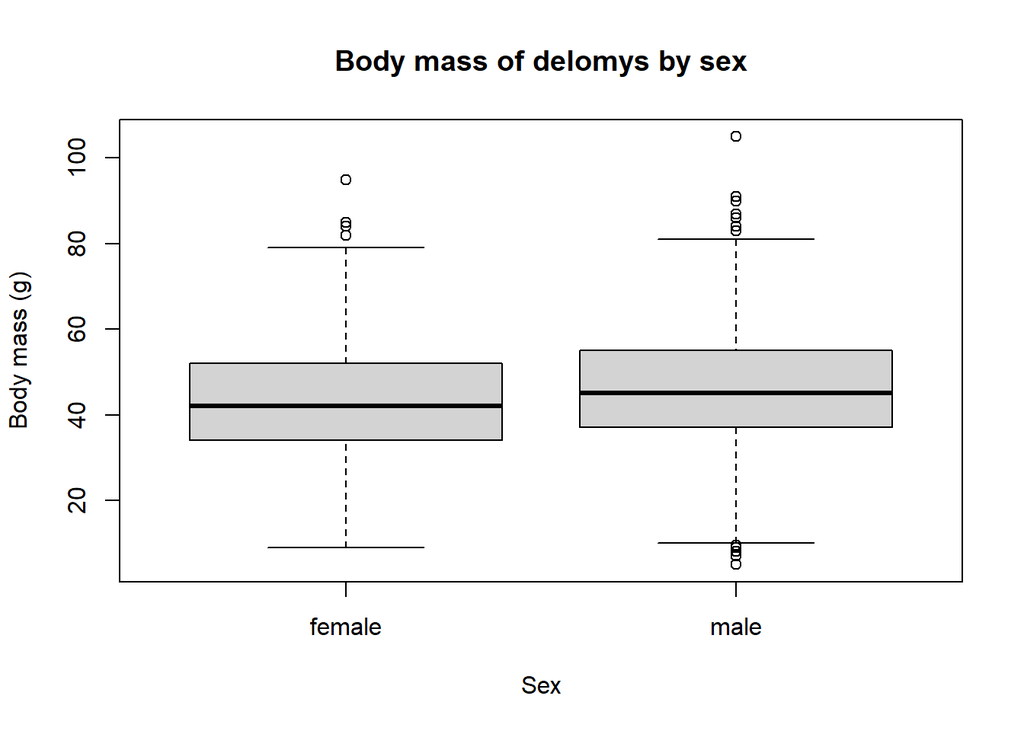

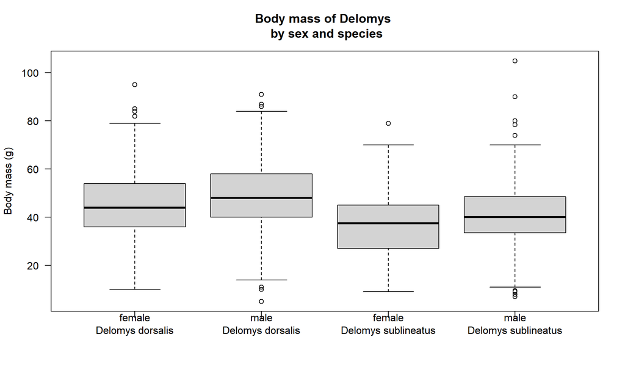

## Data Exploration Questions

### Q1

Based on the graphical interpretation of the scatterplot, the relationship between body mass and length appears to be a positive relationship in which as body mass of Delomys species increase, the body length also increases. This relationship does appear to be linear in that there is a general aggregation of points that could have a line fit through these data; however, there are several outliers where the body length is quite large compared to other species with similar body mass.

### Q2

The histogram for Delomys body mass data appears to almost be normally-distributed as more data are distributed in the center of the range from 0-100 but it is also skewed a bit to the left. The histogram for Delomys body length does not appear to be normally-distributed at all. There are more data in the range from 100-150 and there are some above 200.

### Q3

The unconditioned body masses and body length are not normally-distributed. Based on the normality (Shapiro-Wilk) tests for these data, both p-values are below 0.05 which suggests that we can reject the null hypothesis that body mass and body length are normally-distributed. For body length, the normality test further strengthens our argument that these data are not normally-distributed as interpreted in the visual assessment of the histogram. For body mass, my visual assessment originally indicated that it may be normally-distributed even though it was a bit skewed to the left, but the normality test suggests that those data are not normally-distibuted.

### Q4

Based on the boxplot for body mass by species, it appears that *Delomys dorsalis* is larger than *Delomys sublineatus*. Additionally, it appears that female *Delomys* are generally smaller than males, although there is some variation and the medians of these data are pretty close. We can also see similar patterns in the conditional boxplot based on sex and species which indicates that the females of each species may tend to be smaller than the males and that *Delomys dorsalis* is larger than *Delomys sublineatus*.

# Model Building

Fitting 5 models with Delomys data

```r
# Model 1:  simple linear regression body_length ~ body_mass
fit1 = lm(body_length ~ body_mass, data = delomys)

# Model 2: 1-way ANOVA body_mass ~ sex
fit2 = lm(body_mass ~ sex, data = delomys)
anova_fit2 = anova(fit2)

# Model 3: 1-way ANOVA body_mass ~ binomial
fit3 = lm(body_mass ~ binomial, data = delomys)
anova_fit3 = anova(fit3)

# Model 4: 2-way additive ANOVA body_mass ~ sex + binomial
fit4 = lm(body_mass ~ sex + binomial, data = delomys)
anova_fit4 = anova(fit4)

# Model 5: 2-way factorial ANOVA body_mass ~ sex * binomial
fit5 = lm(body_mass ~ sex * binomial, data = delomys)
anova_fit5 = anova(fit5)
```

## Model Diagnostics

### Histograms of residuals for each model

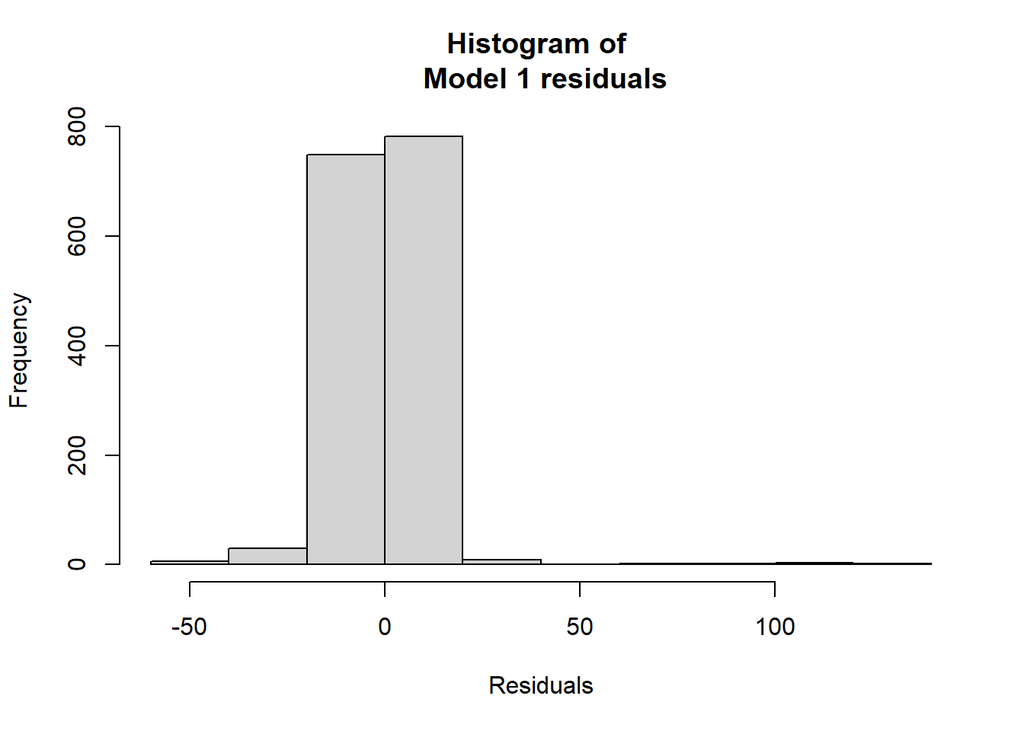

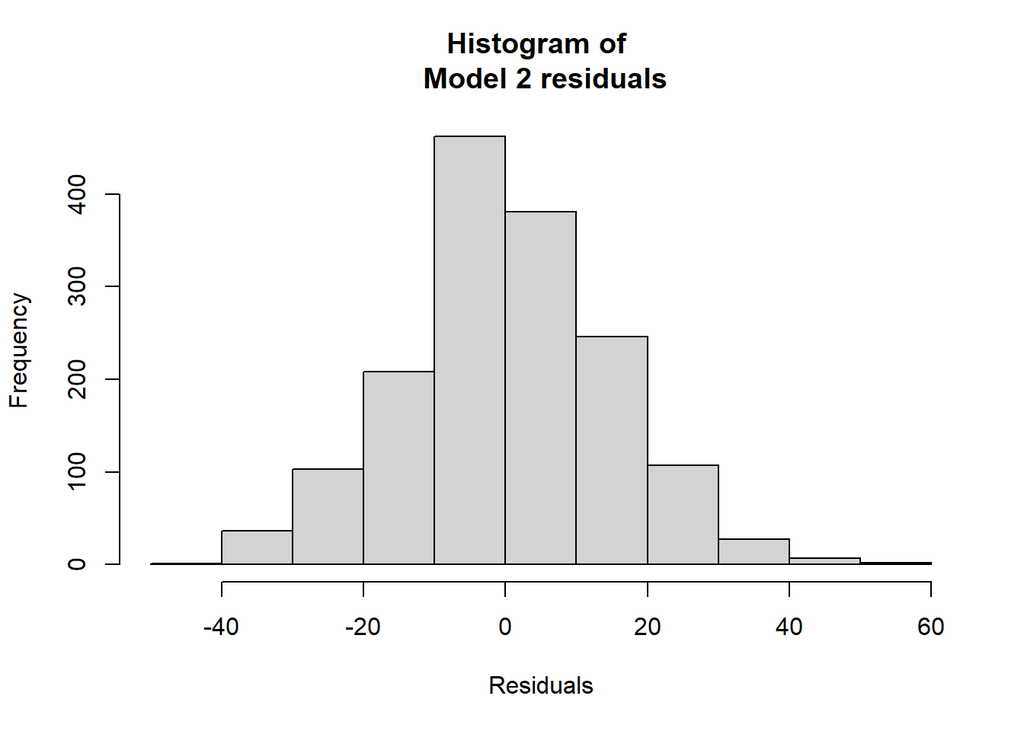

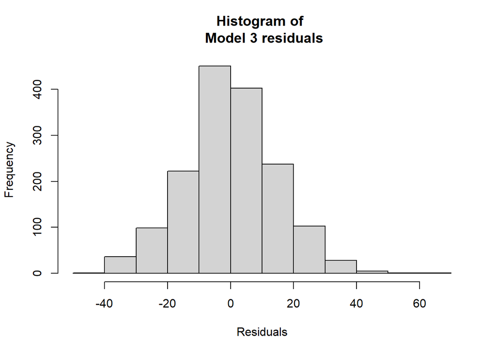

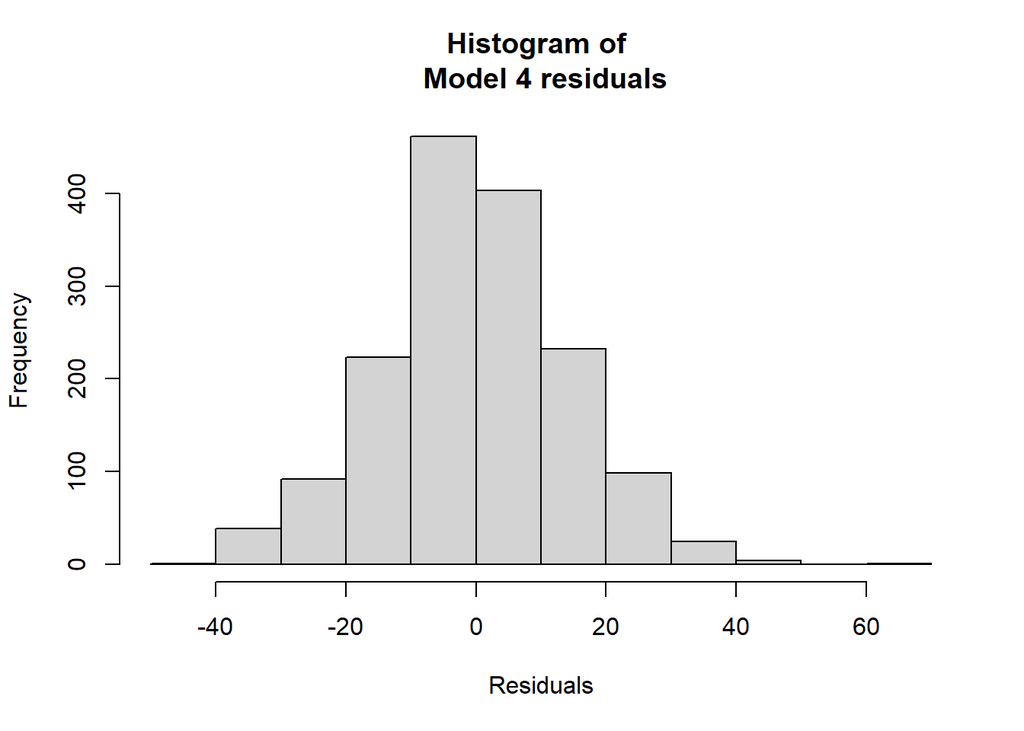

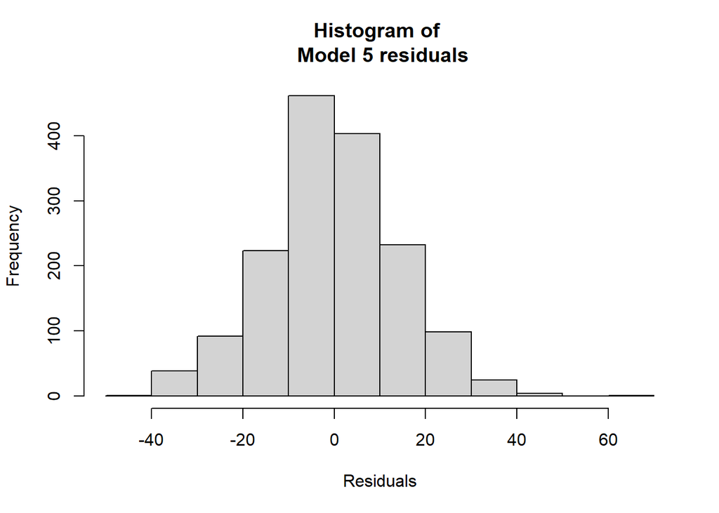

### Shapiro tests for each of the model residuals

```r
shapiro.test(residuals(fit1))
```

```
##
##  Shapiro-Wilk normality test
##
## data:  residuals(fit1)
## W = 0.73462, p-value < 2.2e-16
```

```r
shapiro.test(residuals(fit2))
```

```
##
##  Shapiro-Wilk normality test
##
## data:  residuals(fit2)
## W = 0.99563, p-value = 0.0001541
```

```r
shapiro.test(residuals(fit3))
```

```
##
##  Shapiro-Wilk normality test
##
## data:  residuals(fit3)
## W = 0.99535, p-value = 8.103e-05
```

```r
shapiro.test(residuals(fit4))
```

```
##
##  Shapiro-Wilk normality test
##
## data:  residuals(fit4)
## W = 0.99525, p-value = 6.805e-05
```

```r
shapiro.test(residuals(fit5))
```

```
##
##  Shapiro-Wilk normality test
##
## data:  residuals(fit5)
## W = 0.99526, p-value = 6.816e-05
```

### Model Diagnostics Questions

#### Q5

Based on just the graphical interpretation for residuals of the models, it appears that all but model 1 appear to be almost normally-distributed with a bit of a skew to the left. However, based on the normality (Shapiro-Wilks) tests, none of the residuals for these models are normally-distributed as they all have p-values below 0.05.

## Model Interpretation

### Coefficient table: body length

**Coefficient Table for Model 1**

|  | Estimate | Std. Error | t value | Pr(>\|t\|) |
| --- | --- | --- | --- | --- |
| (Intercept) | 76.1246565 | 0.9158120 | 83.12258 | 0 |
| body_mass | 0.8754988 | 0.0196905 | 44.46298 | 0 |

### Coefficient tables: body mass

**Coefficient Table for Model 2**

|  | Estimate | Std. Error | t value | Pr(>\|t\|) |
| --- | --- | --- | --- | --- |
| (Intercept) | 42.711465 | 0.5288929 | 80.756355 | 0.0000000 |
| sexmale | 2.784133 | 0.7456117 | 3.734024 | 0.0001951 |

**Coefficient table Model 3**

|  | Estimate | Std. Error | t value | Pr(>\|t\|) |
| --- | --- | --- | --- | --- |
| (Intercept) | 46.752427 | 0.4499933 | 103.89582 | 0 |
| binomialDelomys sublineatus | -7.683058 | 0.7604562 | -10.10322 | 0 |

**Coefficient table Model 4**

|  | Estimate | Std. Error | t value | Pr(>\|t\|) |
| --- | --- | --- | --- | --- |
| (Intercept) | 45.070355 | 0.5556429 | 81.113891 | 0e+00 |
| sexmale | 3.795395 | 0.7259609 | 5.228099 | 2e-07 |
| binomialDelomys sublineatus | -8.193492 | 0.7609985 | -10.766764 | 0e+00 |

**Coefficient table Model 5**

|  | Estimate | Std. Error | t value | Pr(>\|t\|) |
| --- | --- | --- | --- | --- |
| (Intercept) | 45.0554562 | 0.6052973 | 74.4352459 | 0.0000000 |
| sexmale | 3.8280908 | 0.8966667 | 4.2692460 | 0.0000208 |
| binomialDelomys sublineatus | -8.1417394 | 1.1281046 | -7.2171847 | 0.0000000 |
| sexmale:binomialDelomys sublineatus | -0.0950187 | 1.5285856 | -0.0621612 | 0.9504424 |

### ANOVA Tables: body mass models

**ANOVA Model Fit 2**

```
## Analysis of Variance Table
##
## Response: body_mass
##             Df Sum Sq Mean Sq F value    Pr(>F)
## sex          1   3062 3061.68  13.943 0.0001951 ***
## Residuals 1578 346507  219.59
## ---
## Signif. codes:  0 '***' 0.001 '**' 0.01 '*' 0.05 '.' 0.1 ' ' 1
```

**ANOVA Model Fit 3**

```
## Analysis of Variance Table
##
## Response: body_mass
##             Df Sum Sq Mean Sq F value    Pr(>F)
## binomial     1  21290 21289.7  102.08 < 2.2e-16 ***
## Residuals 1583 330164   208.6
## ---
## Signif. codes:  0 '***' 0.001 '**' 0.01 '*' 0.05 '.' 0.1 ' ' 1
```

**ANOVA Model Fit 4**

```
## Analysis of Variance Table
##
## Response: body_mass
##             Df Sum Sq Mean Sq F value    Pr(>F)
## sex          1   3062  3061.7  14.958 0.0001144 ***
## binomial     1  23727 23727.1 115.923 < 2.2e-16 ***
## Residuals 1577 322780   204.7
## ---
## Signif. codes:  0 '***' 0.001 '**' 0.01 '*' 0.05 '.' 0.1 ' ' 1
```

**ANOVA Model Fit 5**

```
## Analysis of Variance Table
##
## Response: body_mass
##                Df Sum Sq Mean Sq  F value    Pr(>F)
## sex             1   3062  3061.7  14.9489  0.000115 ***
## binomial        1  23727 23727.1 115.8500 < 2.2e-16 ***
## sex:binomial    1      1     0.8   0.0039  0.950442
## Residuals    1576 322779   204.8
## ---
## Signif. codes:  0 '***' 0.001 '**' 0.01 '*' 0.05 '.' 0.1 ' ' 1
```

### Model Interpretation Questions

#### Q7

0.88 is the magnitude of the mass/length relationship

#### Q8

The expected body length of an animal that weighs 100g is 163.67 mm. Which is calculated from the coefficient table using the intercept and the magnitude as below.

76.12 + (0.87 * 100) = 163.67 mm (if it is actually in those units)

#### Q9

The expected body length of an animal that weighs 0g is 76.12.

#### Q10

Female is the base level for sex.

#### Q11

*Delomys dorsalis* is the base level for binomial.

#### Q12

Based on these coefficient tables from the models and also the visual interpretation from above, male is the heavier sex.

#### Q13

Based on these coefficient tables from the models and also the visual interpretation from above, *Delomys dorsalis* is the heavier species. We can tell this from the Model 3 coefficient table, as the estimate for *Delomys sublineatus* is a negative number.

#### Q14

Yes, sex and species are significant predictors for body mass.

#### Q15

There is not a significant interaction based on the p-value of the ANOVA for model fit 5 which is 0.95.

## Model Comparison: Body Mass

```r
# Calculate the AIC values for each of the body mass models

AIC(fit2)
```

```
## [1] 13006.8
```

```r
AIC(fit3)
```

```
## [1] 12966.36
```

```r
AIC(fit4)
```

```
## [1] 12896.73
```

```r
AIC(fit5)
```

```
## [1] 12898.72
```

### Model Comparison Questions

#### Q17

Model Fit 4 and 5 have the lowest AIC values.